# Bio Data Mining

## *Lecture 1: Introduction of data mining*

Seok-Jun Hong (hongseokjun@skku.edu)

Department of Global Biomedical Engineering, SKKU

[COMBINE Lab](https://combinelab.net/)

# Notice

- A major subject for the 4th year of undergraduate students (e.g., BME, Biology, Pharmacology, Medicine)
- Introduction of a wide range of data mining techniques
- More practical use and less theory (code implementation)
- 13 weeks of course except for the mid-term and final exams (no assignment/project)
- Both exams will be based on essay questions.
- Relative grading system (A+/A/A-: 40%, B+/B/B-: 50%, C-D: 10%)
- Not determined whether the exam will be online or offline (will be posted soon).

# Definition of Data Mining

[figure not shown]

Wikipedia: **Data mining** is a process of discovering patterns in large data sets involving methods at the intersection of machine learning, statistics, and database systems.

## How is it different from Machine Learning?

[output not shown]

[figure not shown]

# Type of Data Mining (or Machine Learning)

- Whether it is used for verification purpose or pattern discovery purpose:
  - Verification vs. Discovery
- Whether or not they are trained with supervision based on a prior knowledge:
  - Supervised vs. Unsupervised vs. Semisupervised vs. Reinforcement Learning
- Whether they work by simply comparing new data points to known data points or instead by detecting patterns in the training data and building a predictive model:
  - Instance-based vs. model-based learning
- Whether or not they can learn increamentally on the fly:
  - Online vs. Batch learning

# Verification

- Aim: To assess whether the data support my a priori hypothesis
- Examples of methods:
  - Two-sample t-test and Analysis of Variance (ANOVA; e.g. compare the height between three independent groups)
  - Regression
    - r-square value (Goodness-of-fit: how much my hypothetical model explains the data?)
- Statistical hypothesis testing based on p value

# Discovery

- Aim: To learn the organizational rule of big data ("Description") and to furthermore predict their patterns in unseen cases ("Prediction")
- Taxomony
  - Description (Unsupervised): Clustering, Summarization (or reduction), Link analysis
  - Prediction (Supervised): Regression, Classification

# Supervised learning

- The training set you feed to the algorithm includes the desired solution, called *labels*.

[figure not shown]

  *Figure 1. A labeled training set for spam classification (an example of supervised learning)*
- Type:
  - *Classification*: Training the algorithm based on many instances along with their class (e.g. spam or normal).
  - *Regression*: Predicting a targeted *ordinal (and/or continuous)* numeric value (e.g. price of a car) based on a set of *features* (e.g., mileage, age, brand, etc) called *predictor*. In this system, one should provide both predictors and the targeted responders (label).
- Representative supervised learning algorithms:
  - k-Nearest Neighbors
  - Linear Regression
  - Logistic Regression
  - Support Vector Machines (SVMs)
  - Decision Trees and Random Forests
  - Neural networks

# Unsupervised learning

- The training data is unlabeled. The system tries to learn without a teacher.

[figure not shown]

  *Figure 2. An unlabeled training set for unsupervised learning*

### Representative unsupervised learning algorithms

- Clustering: *Detect groups showing similar features (no need to label)*
  - K-Means
  - DBSCAN
  - Hierarchical Cluster Analysis (HCA)
- Visualization and dimensionality reduction: *Feed complex, high dimensional and unlabeled data to find a simpler representation.*
  - Principal Component Analysis (PCA)
  - Non-linear Dimensionality reduction (Manifold learning)
  - t-Distributed Stochastic Neighbor Embedding (t-SNE)

[figure not shown]

- Anomaly or novelty detection: *Identify unusal cases showing excessively deviated feature patterns compared to normal instances in the database.*
  - One-class SVM
  - Isolation Forest

# Semisupervised learning

- When having plenty of unlabeled instances, and few labeled instances.
- A combination of unsupervised and supervised algorithms

[figure not shown]

  *Figure 3. Semisupervised learning with two classes: the unlabeled examples (circles) help classify a new instance (the cross) into the triangle class rather than the square class.*

# Reinforcement learning

- A conceptually different type of algorithm that is based on interaction with the environment.
- The learning system, called an agent in this context, can observe the environment, select and perform actions, and get rewards in return
- There is always a start and an end state for an agent (the AI-driven system); however, there might be different paths for reaching the end state, like a maze.

[figure not shown]

*Figure 4. Reinforcement Learning*

# Supervised learning vs. Reinforcement learning

- **Passive** vs. **Active** learning
  - In supervised learning the learning process is passive. Passive because model learns a mapping from input to output space, without altering the input space as a consequence of its learning.
  - In reinforcement learning, the learning process is active - the agent learns by interacting with its environment thereby changing the very environment it observes.
- **Instructive** vs. **Evaluative** role of supervision
  - In supervised learning, the role of the teacher is instructive.
  - In contrast in reinforcement learning, the teacher feedback is evaluative. And because an action of the agent affects the next action, its effect on the reward is cumulative.

# Hands-on session 1

- Suppose we want to know if money makes people happy.
- So you download the Better Life Index data from the OECD's webstie and stats about gross domestic product (GDP) per capita from the IMF's website.

[figure not shown]

*Table 1. Does Money make people happier?*

[figure not shown]

*Figure 5. Do you see a trend here?*

- Satisfaction seems to go up more or less linearly as the country's GDP per capita increase.
- So you decide to model life satisfaction as a linear function of GDP per capita. This step is called model selection.

[figure not shown]

  *Equation 1. A simple Linear Model*

# Building a prediction framework based on a linear model

```python
import matplotlib.pyplot as plt
import numpy as np
import pandas as pd
import sklearn.linear_model
import os
```

```python
# Load the data
oecd_bli = pd.read_csv("oecd_bli_2015.csv", thousands=',')
gdp_per_capita = pd.read_csv("gdp_per_capita.csv",thousands=',',delimiter='\t',
encoding='latin1', na_values="n/a")
```

```python
def prepare_country_stats(oecd_bli, gdp_per_capita):
    oecd_bli = oecd_bli[oecd_bli["INEQUALITY"]=="TOT"]
    oecd_bli = oecd_bli.pivot(index="Country", columns="Indicator", values="Value")
    gdp_per_capita.rename(columns={"2015": "GDP per capita"}, inplace=True)
    gdp_per_capita.set_index("Country", inplace=True)
    full_country_stats = pd.merge(left=oecd_bli, right=gdp_per_capita,
                                  left_index=True, right_index=True)
    full_country_stats.sort_values(by="GDP per capita", inplace=True)
    remove_indices = [0, 1, 6, 8, 33, 34, 35]
    keep_indices = list(set(range(36)) - set(remove_indices))
    return full_country_stats[["GDP per capita", 'Life satisfaction']].iloc[keep_indices]
```

```python
# Prepare the data
country_stats = prepare_country_stats(oecd_bli, gdp_per_capita)
X = np.c_[country_stats["GDP per capita"]]
y = np.c_[country_stats["Life satisfaction"]]
```

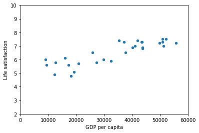

```python
# Visualize the data
country_stats.plot(kind='scatter', x="GDP per capita", y='Life satisfaction')
plt.xlim(0, 60000)
plt.ylim(2, 10)
plt.show()
```

```python
# Select a linear model
model = sklearn.linear_model.LinearRegression()

# Train the model
model.fit(X, y)
```

```
LinearRegression(copy_X=True, fit_intercept=True, n_jobs=None, normalize=False)
```

```
(array([[4.91154459e-05]]), array([4.8530528]))
```

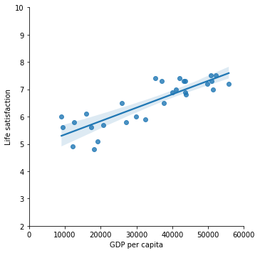

```python
import seaborn as sns
g = sns.lmplot(x="GDP per capita", y='Life satisfaction', data=country_stats, fit_reg=True)
g.set(xlim=(0, 60000))
g.set(ylim=(2, 10))

model.coef_, model.intercept_
```

```python
# Make a prediction for Cyprus
X_new = [[22587]] # Cyprus's GDP per capita
print(model.predict(X_new)) # outputs [[ 5.96242338]]
```

```
[[5.96242338]]
```

# Typical order of machine learning

- Load and prepare relevant data (or variables)
- Visualize data to have a sense and select a hypothetical model
- Train the model using prepared training data
- Apply the trained model to the new 'unseen' cases for prediction

# Main challenges - I

- Insufficient Quantity of Training Data
- Nonrepresentative Training Data
- It is crucial to use a training set that is representative of the cases you want to generalize to.
- Sampling noise (when small sample size), Samling bias (skewed sampling method)

[figure not shown]

  *Figure 6. A more representative training sample*

# Main challenges - II

- Poor-Quality Data (e.g., many outliers, many cases missing some features, excessive noise)
- Irrelevant Features (=garbage in, gargabe out)
  - Option: *Feature selection*, *New feature generation/extraction*
- Overfitting problem

[figure not shown]

*Figure 7. Overfitting the training data*

# Main challenges - II

- Irrelevant Features (=garbage in, gargabe out)
  - Option: *Feature selection*, *New feature generation/extraction*
- Overfitting problem
  - Option1: Simply the model by selecting one with fewer parameters (e.g., a linear model rather than a high-degree polynomial) or by constraining the model (i.e., *regularization*).
  - Option2: Gather more training data
  - Option3: Reduce the noise effect in the training data (e.g., preprocessing to correct apparent errors or remove outliers)
- Underfitting the training data

# Summary of Lecture 1

- Data mining is a set of techniques to 'extract hidden rules' from large-scale data (knowledge discovery).
- Largely divided into 'verification' and 'discovery' (which is in turn categorizable into 'description' and 'prediction' domains) methods.
- Briefly introduced concepts and algorithms of 'supervised', 'unsupervised', 'semisupervised' and 'reinforcement' learning.
- Main challenges to be considered throughout this class (e.g., small sample size, nonrepresentative, poor-quality data, and irrelevant features and over-/under-fitting problems)